# Pandas-Bootcamp-Part4

### DataFrame Iteration

```python
#We are getting back all the column names
for k in units:
    print(k)
```

```
serving_size
calories
total_fat
saturated_fat
cholesterol
sodium
choline
folate
folic_acid
niacin
pantothenic_acid
riboflavin
thiamin
vitamin_a
vitamin_a_rae
carotene_alpha
carotene_beta
cryptoxanthin_beta
lutein_zeaxanthin
lucopene
vitamin_b12
vitamin_b6
vitamin_c
vitamin_d
vitamin_e
tocopherol_alpha
vitamin_k
calcium
copper
irom
magnesium
manganese
phosphorous
potassium
selenium
zink
protein
alanine
arginine
aspartic_acid
```

[output cut: 20 more lines]

```
galactose
glucose
lactose
maltose
sucrose
fat
saturated_fatty_acids
monounsaturated_fatty_acids
polyunsaturated_fatty_acids
fatty_acids_total_trans
alcohol
ash
caffeine
theobromine
water
```

```python
#we are also interested in units associated with each column
for k in units:
    print(k , units[k])
```

```
serving_size 0    g
Name: serving_size, dtype: object
calories 0
Name: calories, dtype: object
total_fat 0    g
Name: total_fat, dtype: object
saturated_fat 0    g
Name: saturated_fat, dtype: object
cholesterol 0    mg
Name: cholesterol, dtype: object
sodium 0    mg
Name: sodium, dtype: object
choline 0    mg
Name: choline, dtype: object
folate 0    mcg
Name: folate, dtype: object
folic_acid 0    mcg
Name: folic_acid, dtype: object
niacin 0    mg
Name: niacin, dtype: object
pantothenic_acid 0    mg
Name: pantothenic_acid, dtype: object
riboflavin 0    mg
Name: riboflavin, dtype: object
thiamin 0    mg
Name: thiamin, dtype: object
vitamin_a 0    IU
Name: vitamin_a, dtype: object
vitamin_a_rae 0    mcg
Name: vitamin_a_rae, dtype: object
carotene_alpha 0    mcg
Name: carotene_alpha, dtype: object
carotene_beta 0    mcg
Name: carotene_beta, dtype: object
cryptoxanthin_beta 0    mcg
Name: cryptoxanthin_beta, dtype: object
lutein_zeaxanthin 0    mcg
Name: lutein_zeaxanthin, dtype: object
lucopene 0
Name: lucopene, dtype: object
```

[output cut: 95 more lines]

```
Name: monounsaturated_fatty_acids, dtype: object
polyunsaturated_fatty_acids 0    g
Name: polyunsaturated_fatty_acids, dtype: object
fatty_acids_total_trans 0    mg
Name: fatty_acids_total_trans, dtype: object
alcohol 0    g
Name: alcohol, dtype: object
ash 0    g
Name: ash, dtype: object
caffeine 0    mg
Name: caffeine, dtype: object
theobromine 0    mg
Name: theobromine, dtype: object
water 0    g
Name: water, dtype: object
```

```python
#But we are not interested in this kind of output
#we are also interested in units associated with each column
#print(k , units[k][0].at[0])
for k in units:
    print(k , units[k][0])
```

```
serving_size g
calories
total_fat g
saturated_fat g
cholesterol mg
sodium mg
choline mg
folate mcg
folic_acid mcg
niacin mg
pantothenic_acid mg
riboflavin mg
thiamin mg
vitamin_a IU
vitamin_a_rae mcg
carotene_alpha mcg
carotene_beta mcg
cryptoxanthin_beta mcg
lutein_zeaxanthin mcg
lucopene
vitamin_b12 mcg
vitamin_b6 mg
vitamin_c mg
vitamin_d IU
vitamin_e mg
tocopherol_alpha mg
vitamin_k mcg
calcium mg
copper mg
irom mg
magnesium mg
manganese mg
phosphorous mg
potassium mg
selenium mcg
zink mg
protein g
alanine g
arginine g
aspartic_acid g
```

[output cut: 20 more lines]

```
galactose
glucose
lactose
maltose
sucrose
fat g
saturated_fatty_acids g
monounsaturated_fatty_acids g
polyunsaturated_fatty_acids g
fatty_acids_total_trans mg
alcohol g
ash g
caffeine mg
theobromine mg
water g
```

- you can notice the gaps here
- few columns do not have the units
- Lets only print the units and look at the gaps

```python
for k in units:
    print(units[k][0])
```

```
g

g
g
mg
mg
mg
mcg
mcg
mg
mg
mg
mg
IU
mcg
mcg
mcg
mcg
mcg

mcg
mg
mg
IU
mg
mg
mcg
mg
mg
mg
mg
mg
mg
mg
mcg
mg
g
g
g
g
```

[output cut: 20 more lines]

```





g
g
g
g
mg
g
g
mg
mg
g
```

```python
#Lets first replace all the empty values with  na
units.replace("" , np.nan)
```

|  | serving_size | calories | total_fat | saturated_fat | cholesterol | sodium | choline | folate | folic_acid | niacin | ... | fat | saturated_fatty_acids | monounsaturated_fatty_acids | polyunsaturated_fatty_acids | fatty_acids_total_trans | alcohol | ash | caffeine | theobromine | water |
| --- | --- | --- | --- | --- | --- | --- | --- | --- | --- | --- | --- | --- | --- | --- | --- | --- | --- | --- | --- | --- | --- |
| 0 | g | NaN | g | g | mg | mg | mg | mcg | mcg | mg | ... | g | g | g | g | mg | g | g | mg | mg | g |

1 rows × 75 columns

```python
#Now we drop all the columns that contain na
units.replace("" , np.nan).dropna(axis = 1)
```

|  | serving_size | total_fat | saturated_fat | cholesterol | sodium | choline | folate | folic_acid | niacin | pantothenic_acid | ... | fat | saturated_fatty_acids | monounsaturated_fatty_acids | polyunsaturated_fatty_acids | fatty_acids_total_trans | alcohol | ash | caffeine | theobromine | water |
| --- | --- | --- | --- | --- | --- | --- | --- | --- | --- | --- | --- | --- | --- | --- | --- | --- | --- | --- | --- | --- | --- |
| 0 | g | g | g | mg | mg | mg | mcg | mcg | mg | mg | ... | g | g | g | g | mg | g | g | mg | mg | g |

1 rows × 66 columns

```python
#Assign this to the units variable
units = units.replace("" , np.nan).dropna(axis = 1)
```

```python
units.shape
```

```
(1, 66)
```

- Earlier we had 75 columns and now after dropping columns with NA , we got 66 columns

```python
for k in units:
    print(units[k][0])
```

```
g
g
g
mg
mg
mg
mcg
mcg
mg
mg
mg
mg
IU
mcg
mcg
mcg
mcg
mcg
mcg
mg
mg
IU
mg
mg
mcg
mg
mg
mg
mg
mg
mg
mg
mcg
mg
g
g
g
g
g
g
```

[output cut: 11 more lines]

```
g
g
g
g
g
g
g
g
g
mg
g
g
mg
mg
g
```

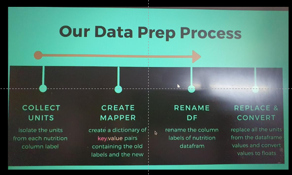

### Create a Mapper

```python
#We want to create a Dictionary with the old column name and New column name
#this is a Dictionary comprehension
```

```python
mapper = {k : k + "_" + units[k][0]  for k in units}
```

```python
mapper
```

```
{'serving_size': 'serving_size_g',
 'total_fat': 'total_fat_g',
 'saturated_fat': 'saturated_fat_g',
 'cholesterol': 'cholesterol_mg',
 'sodium': 'sodium_mg',
 'choline': 'choline_mg',
 'folate': 'folate_mcg',
 'folic_acid': 'folic_acid_mcg',
 'niacin': 'niacin_mg',
 'pantothenic_acid': 'pantothenic_acid_mg',
 'riboflavin': 'riboflavin_mg',
 'thiamin': 'thiamin_mg',
 'vitamin_a': 'vitamin_a_IU',
 'vitamin_a_rae': 'vitamin_a_rae_mcg',
 'carotene_alpha': 'carotene_alpha_mcg',
 'carotene_beta': 'carotene_beta_mcg',
 'cryptoxanthin_beta': 'cryptoxanthin_beta_mcg',
 'lutein_zeaxanthin': 'lutein_zeaxanthin_mcg',
 'vitamin_b12': 'vitamin_b12_mcg',
 'vitamin_b6': 'vitamin_b6_mg',
 'vitamin_c': 'vitamin_c_mg',
 'vitamin_d': 'vitamin_d_IU',
 'vitamin_e': 'vitamin_e_mg',
 'tocopherol_alpha': 'tocopherol_alpha_mg',
 'vitamin_k': 'vitamin_k_mcg',
 'calcium': 'calcium_mg',
 'copper': 'copper_mg',
 'irom': 'irom_mg',
 'magnesium': 'magnesium_mg',
 'manganese': 'manganese_mg',
 'phosphorous': 'phosphorous_mg',
 'potassium': 'potassium_mg',
 'selenium': 'selenium_mcg',
 'zink': 'zink_mg',
 'protein': 'protein_g',
 'alanine': 'alanine_g',
 'arginine': 'arginine_g',
 'aspartic_acid': 'aspartic_acid_g',
 'cystine': 'cystine_g',
 'glutamic_acid': 'glutamic_acid_g',
```

[output cut: 11 more lines]

```
 'tyrosine': 'tyrosine_g',
 'valine': 'valine_g',
 'carbohydrate': 'carbohydrate_g',
 'fiber': 'fiber_g',
 'sugars': 'sugars_g',
 'fat': 'fat_g',
 'saturated_fatty_acids': 'saturated_fatty_acids_g',
 'monounsaturated_fatty_acids': 'monounsaturated_fatty_acids_g',
 'polyunsaturated_fatty_acids': 'polyunsaturated_fatty_acids_g',
 'fatty_acids_total_trans': 'fatty_acids_total_trans_mg',
 'alcohol': 'alcohol_g',
 'ash': 'ash_g',
 'caffeine': 'caffeine_mg',
 'theobromine': 'theobromine_mg',
 'water': 'water_g'}
```

```python
#Now we have the Dictionary of old column names and new column names which we can now replace in the nutri dataset
nutri.rename(columns = mapper)
```

| name | serving_size_g | calories | total_fat_g | saturated_fat_g | cholesterol_mg | sodium_mg | choline_mg | folate_mcg | folic_acid_mcg | niacin_mg | ... | fat_g | saturated_fatty_acids_g | monounsaturated_fatty_acids_g | polyunsaturated_fatty_acids_g | fatty_acids_total_trans_mg | alcohol_g | ash_g | caffeine_mg | theobromine_mg | water_g |
| --- | --- | --- | --- | --- | --- | --- | --- | --- | --- | --- | --- | --- | --- | --- | --- | --- | --- | --- | --- | --- | --- |
| Cornstarch | 100 g | 381 | 0.1g | NaN | 0 | 9.00 mg | 0.4 mg | 0.00 mcg | 0.00 mcg | 0.000 mg | ... | 0.05 g | 0.009 g | 0.016 g | 0.025 g | 0.00 mg | 0.0 g | 0.09 g | 0.00 mg | 0.00 mg | 8.32 g |
| Nuts, pecans | 100 g | 691 | 72g | 6.2g | 0 | 0.00 mg | 40.5 mg | 22.00 mcg | 0.00 mcg | 1.167 mg | ... | 71.97 g | 6.180 g | 40.801 g | 21.614 g | 0.00 mg | 0.0 g | 1.49 g | 0.00 mg | 0.00 mg | 3.52 g |
| Eggplant, raw | 100 g | 25 | 0.2g | NaN | 0 | 2.00 mg | 6.9 mg | 22.00 mcg | 0.00 mcg | 0.649 mg | ... | 0.18 g | 0.034 g | 0.016 g | 0.076 g | 0.00 mg | 0.0 g | 0.66 g | 0.00 mg | 0.00 mg | 92.30 g |
| Teff, uncooked | 100 g | 367 | 2.4g | 0.4g | 0 | 12.00 mg | 13.1 mg | 0 | 0 | 3.363 mg | ... | 2.38 g | 0.449 g | 0.589 g | 1.071 g | 0 | 0 | 2.37 g | 0 | 0 | 8.82 g |
| Sherbet, orange | 100 g | 144 | 2g | 1.2g | 1mg | 46.00 mg | 7.7 mg | 4.00 mcg | 0.00 mcg | 0.063 mg | ... | 2.00 g | 1.160 g | 0.530 g | 0.080 g | 1.00 mg | 0.0 g | 0.40 g | 0.00 mg | 0.00 mg | 66.10 g |
| ... | ... | ... | ... | ... | ... | ... | ... | ... | ... | ... | ... | ... | ... | ... | ... | ... | ... | ... | ... | ... | ... |
| Beef, raw, all grades, trimmed to 0" fat, separable lean and fat, boneless, top round roast, round | 100 g | 125 | 3.5g | 1.4g | 62mg | 54.00 mg | 64.5 mg | 4.00 mcg | 0.00 mcg | 6.422 mg | ... | 3.50 g | 1.353 g | 1.554 g | 0.244 g | 62.00 mg | 0.0 g | 1.11 g | 0.00 mg | 0.00 mg | 72.51 g |
| Lamb, cooked, separable lean only, composite of trimmed retail cuts, frozen, imported, New Zealand | 100 g | 206 | 8.9g | 3.9g | 109mg | 50.00 mg | 0 | 0.00 mcg | 0.00 mcg | 7.680 mg | ... | 8.86 g | 3.860 g | 3.480 g | 0.520 g | 109.00 mg | 0 | 1.60 g | 0 | 0 | 59.95 g |
| Lamb, raw, separable lean and fat, composite of trimmed retail cuts, frozen, imported, New Zealand | 100 g | 277 | 23g | 12g | 78mg | 39.00 mg | 0 | 1.00 mcg | 0.00 mcg | 6.550 mg | ... | 22.74 g | 11.570 g | 8.720 g | 0.980 g | 78.00 mg | 0 | 0.92 g | 0 | 0 | 59.80 g |
| Beef, raw, all grades, trimmed to 0" fat, separable lean only, boneless, eye of round roast, round | 100 g | 121 | 3g | 1.1g | 60mg | 53.00 mg | 64.2 mg | 4.00 mcg | 0.00 mcg | 6.720 mg | ... | 3.04 g | 1.086 g | 1.266 g | 0.233 g | 60.00 mg | 0.0 g | 1.10 g | 0.00 mg | 0.00 mg | 73.43 g |
| Beef, raw, all grades, trimmed to 0" fat, separable lean only, boneless, eye of round steak, round | 100 g | 121 | 3g | 1.1g | 60mg | 53.00 mg | 64.2 mg | 4.00 mcg | 0.00 mcg | 6.720 mg | ... | 3.04 g | 1.086 g | 1.266 g | 0.233 g | 60.00 mg | 0.0 g | 1.10 g | 0.00 mg | 0.00 mg | 73.43 g |

8789 rows × 75 columns

```python
nutri.rename(columns = mapper , inplace = True)
```

```python
nutri.head(2)
```

| name | serving_size_g | calories | total_fat_g | saturated_fat_g | cholesterol_mg | sodium_mg | choline_mg | folate_mcg | folic_acid_mcg | niacin_mg | ... | fat_g | saturated_fatty_acids_g | monounsaturated_fatty_acids_g | polyunsaturated_fatty_acids_g | fatty_acids_total_trans_mg | alcohol_g | ash_g | caffeine_mg | theobromine_mg | water_g |
| --- | --- | --- | --- | --- | --- | --- | --- | --- | --- | --- | --- | --- | --- | --- | --- | --- | --- | --- | --- | --- | --- |
| Cornstarch | 100 g | 381 | 0.1g | NaN | 0 | 9.00 mg | 0.4 mg | 0.00 mcg | 0.00 mcg | 0.000 mg | ... | 0.05 g | 0.009 g | 0.016 g | 0.025 g | 0.00 mg | 0.0 g | 0.09 g | 0.00 mg | 0.00 mg | 8.32 g |
| Nuts, pecans | 100 g | 691 | 72g | 6.2g | 0 | 0.00 mg | 40.5 mg | 22.00 mcg | 0.00 mcg | 1.167 mg | ... | 71.97 g | 6.180 g | 40.801 g | 21.614 g | 0.00 mg | 0.0 g | 1.49 g | 0.00 mg | 0.00 mg | 3.52 g |

2 rows × 75 columns

- Observe that we managed to replace all the column names with the new column names where there were units.

#### Now that we know which columns have values and which don't . We can go ahead and simply remove the units from the values.

- And we can get purely numeric columns that we are looking for

### Removing Units from values

We want to remove everythin that is non-numeric from our values

- We will use the df.replace() method with Regex pattern

```python
nutri.replace('[a-zA-Z]' , '' , regex = True , inplace = True)
```

```python
nutri.head(5)
```

| name | serving_size_g | calories | total_fat_g | saturated_fat_g | cholesterol_mg | sodium_mg | choline_mg | folate_mcg | folic_acid_mcg | niacin_mg | ... | fat_g | saturated_fatty_acids_g | monounsaturated_fatty_acids_g | polyunsaturated_fatty_acids_g | fatty_acids_total_trans_mg | alcohol_g | ash_g | caffeine_mg | theobromine_mg | water_g |
| --- | --- | --- | --- | --- | --- | --- | --- | --- | --- | --- | --- | --- | --- | --- | --- | --- | --- | --- | --- | --- | --- |
| Cornstarch | 100 | 381 | 0.1 | NaN | 0 | 9.00 | 0.4 | 0.00 | 0.00 | 0.000 | ... | 0.05 | 0.009 | 0.016 | 0.025 | 0.00 | 0.0 | 0.09 | 0.00 | 0.00 | 8.32 |
| Nuts, pecans | 100 | 691 | 72 | 6.2 | 0 | 0.00 | 40.5 | 22.00 | 0.00 | 1.167 | ... | 71.97 | 6.180 | 40.801 | 21.614 | 0.00 | 0.0 | 1.49 | 0.00 | 0.00 | 3.52 |
| Eggplant, raw | 100 | 25 | 0.2 | NaN | 0 | 2.00 | 6.9 | 22.00 | 0.00 | 0.649 | ... | 0.18 | 0.034 | 0.016 | 0.076 | 0.00 | 0.0 | 0.66 | 0.00 | 0.00 | 92.30 |
| Teff, uncooked | 100 | 367 | 2.4 | 0.4 | 0 | 12.00 | 13.1 | 0 | 0 | 3.363 | ... | 2.38 | 0.449 | 0.589 | 1.071 | 0 | 0 | 2.37 | 0 | 0 | 8.82 |
| Sherbet, orange | 100 | 144 | 2 | 1.2 | 1 | 46.00 | 7.7 | 4.00 | 0.00 | 0.063 | ... | 2.00 | 1.160 | 0.530 | 0.080 | 1.00 | 0.0 | 0.40 | 0.00 | 0.00 | 66.10 |

5 rows × 75 columns

- It looks good now
- But almost all the columns in our dataset are of dtype : Object

```python
nutri.dtypes
```

```
serving_size_g     object
calories            int64
total_fat_g        object
saturated_fat_g    object
cholesterol_mg     object
                    ...
alcohol_g          object
ash_g              object
caffeine_mg        object
theobromine_mg     object
water_g            object
Length: 75, dtype: object
```

```python
nutri.dtypes.value_counts()
```

```
object    73
int64      2
dtype: int64
```

```python
nutri = nutri.astype(float)
```

```python
nutri.dtypes.value_counts()
```

```
float64    75
dtype: int64
```

```python
nutri.info(verbose = False)
```

```
<class 'pandas.core.frame.DataFrame'>
Index: 8789 entries, Cornstarch to Beef, raw, all grades, trimmed to 0" fat, separable lean only, boneless, eye of round steak, round
Columns: 75 entries, serving_size_g to water_g
dtypes: float64(75)
memory usage: 5.1+ MB
```

Now we have 75 columns of dtype "float"

### Filtering in 2D

```python
#This is case-sensitive
nutri.filter(like = "Octopus", axis = 0)
```

| name | serving_size_g | calories | total_fat_g | saturated_fat_g | cholesterol_mg | sodium_mg | choline_mg | folate_mcg | folic_acid_mcg | niacin_mg | ... | fat_g | saturated_fatty_acids_g | monounsaturated_fatty_acids_g | polyunsaturated_fatty_acids_g | fatty_acids_total_trans_mg | alcohol_g | ash_g | caffeine_mg | theobromine_mg | water_g |
| --- | --- | --- | --- | --- | --- | --- | --- | --- | --- | --- | --- | --- | --- | --- | --- | --- | --- | --- | --- | --- | --- |
| Octopus (Alaska Native) | 100.0 | 56.0 | 0.8 | 0.2 | 41.0 | 0.0 | 0.0 | 0.0 | 0.0 | 2.0 | ... | 0.8 | 0.2 | 0.0 | 0.2 | 41.0 | 0.0 | 1.5 | 0.0 | 0.0 | 84.0 |

1 rows × 75 columns

```python
#This is case-sensitive
nutri.filter(like = "octopus", axis = 0)
```

| name | serving_size_g | calories | total_fat_g | saturated_fat_g | cholesterol_mg | sodium_mg | choline_mg | folate_mcg | folic_acid_mcg | niacin_mg | ... | fat_g | saturated_fatty_acids_g | monounsaturated_fatty_acids_g | polyunsaturated_fatty_acids_g | fatty_acids_total_trans_mg | alcohol_g | ash_g | caffeine_mg | theobromine_mg | water_g |
| --- | --- | --- | --- | --- | --- | --- | --- | --- | --- | --- | --- | --- | --- | --- | --- | --- | --- | --- | --- | --- | --- |
| Mollusks, raw, common, octopus | 100.0 | 82.0 | 1.0 | 0.2 | 48.0 | 230.0 | 65.0 | 16.0 | 0.0 | 2.10 | ... | 1.04 | 0.227 | 0.162 | 0.239 | 48.0 | 0.0 | 1.6 | 0.0 | 0.0 | 80.25 |
| Mollusks, moist heat, cooked, common, octopus | 100.0 | 164.0 | 2.1 | 0.5 | 96.0 | 460.0 | 81.0 | 24.0 | 0.0 | 3.78 | ... | 2.08 | 0.453 | 0.324 | 0.477 | 96.0 | 0.0 | 3.2 | 0.0 | 0.0 | 60.50 |

2 rows × 75 columns

#### filter() method also supports Regular expressions

```python
#filter with regex
nutri.filter(regex = 'octopus' , axis = 0 )
```

| name | serving_size_g | calories | total_fat_g | saturated_fat_g | cholesterol_mg | sodium_mg | choline_mg | folate_mcg | folic_acid_mcg | niacin_mg | ... | fat_g | saturated_fatty_acids_g | monounsaturated_fatty_acids_g | polyunsaturated_fatty_acids_g | fatty_acids_total_trans_mg | alcohol_g | ash_g | caffeine_mg | theobromine_mg | water_g |
| --- | --- | --- | --- | --- | --- | --- | --- | --- | --- | --- | --- | --- | --- | --- | --- | --- | --- | --- | --- | --- | --- |
| Mollusks, raw, common, octopus | 100.0 | 82.0 | 1.0 | 0.2 | 48.0 | 230.0 | 65.0 | 16.0 | 0.0 | 2.10 | ... | 1.04 | 0.227 | 0.162 | 0.239 | 48.0 | 0.0 | 1.6 | 0.0 | 0.0 | 80.25 |
| Mollusks, moist heat, cooked, common, octopus | 100.0 | 164.0 | 2.1 | 0.5 | 96.0 | 460.0 | 81.0 | 24.0 | 0.0 | 3.78 | ... | 2.08 | 0.453 | 0.324 | 0.477 | 96.0 | 0.0 | 3.2 | 0.0 | 0.0 | 60.50 |

2 rows × 75 columns

```python
#filter with regex
#we use the character set to ignore the case
nutri.filter(regex = '[oO]ctopus' , axis = 0 )
```

| name | serving_size_g | calories | total_fat_g | saturated_fat_g | cholesterol_mg | sodium_mg | choline_mg | folate_mcg | folic_acid_mcg | niacin_mg | ... | fat_g | saturated_fatty_acids_g | monounsaturated_fatty_acids_g | polyunsaturated_fatty_acids_g | fatty_acids_total_trans_mg | alcohol_g | ash_g | caffeine_mg | theobromine_mg | water_g |
| --- | --- | --- | --- | --- | --- | --- | --- | --- | --- | --- | --- | --- | --- | --- | --- | --- | --- | --- | --- | --- | --- |
| Octopus (Alaska Native) | 100.0 | 56.0 | 0.8 | 0.2 | 41.0 | 0.0 | 0.0 | 0.0 | 0.0 | 2.00 | ... | 0.80 | 0.200 | 0.000 | 0.200 | 41.0 | 0.0 | 1.5 | 0.0 | 0.0 | 84.00 |
| Mollusks, raw, common, octopus | 100.0 | 82.0 | 1.0 | 0.2 | 48.0 | 230.0 | 65.0 | 16.0 | 0.0 | 2.10 | ... | 1.04 | 0.227 | 0.162 | 0.239 | 48.0 | 0.0 | 1.6 | 0.0 | 0.0 | 80.25 |
| Mollusks, moist heat, cooked, common, octopus | 100.0 | 164.0 | 2.1 | 0.5 | 96.0 | 460.0 | 81.0 | 24.0 | 0.0 | 3.78 | ... | 2.08 | 0.453 | 0.324 | 0.477 | 96.0 | 0.0 | 3.2 | 0.0 | 0.0 | 60.50 |

3 rows × 75 columns

Remember : "filter" filters only Index and Column labels

#### REGEX ignore case

```python
#We can completely ignore the case and match the pattern in a completely insensitive way
nutri.filter(regex ='(?i)octopus' , axis = 0)
```

| name | serving_size_g | calories | total_fat_g | saturated_fat_g | cholesterol_mg | sodium_mg | choline_mg | folate_mcg | folic_acid_mcg | niacin_mg | ... | fat_g | saturated_fatty_acids_g | monounsaturated_fatty_acids_g | polyunsaturated_fatty_acids_g | fatty_acids_total_trans_mg | alcohol_g | ash_g | caffeine_mg | theobromine_mg | water_g |
| --- | --- | --- | --- | --- | --- | --- | --- | --- | --- | --- | --- | --- | --- | --- | --- | --- | --- | --- | --- | --- | --- |
| Octopus (Alaska Native) | 100.0 | 56.0 | 0.8 | 0.2 | 41.0 | 0.0 | 0.0 | 0.0 | 0.0 | 2.00 | ... | 0.80 | 0.200 | 0.000 | 0.200 | 41.0 | 0.0 | 1.5 | 0.0 | 0.0 | 84.00 |
| Mollusks, raw, common, octopus | 100.0 | 82.0 | 1.0 | 0.2 | 48.0 | 230.0 | 65.0 | 16.0 | 0.0 | 2.10 | ... | 1.04 | 0.227 | 0.162 | 0.239 | 48.0 | 0.0 | 1.6 | 0.0 | 0.0 | 80.25 |
| Mollusks, moist heat, cooked, common, octopus | 100.0 | 164.0 | 2.1 | 0.5 | 96.0 | 460.0 | 81.0 | 24.0 | 0.0 | 3.78 | ... | 2.08 | 0.453 | 0.324 | 0.477 | 96.0 | 0.0 | 3.2 | 0.0 | 0.0 | 60.50 |

3 rows × 75 columns

```python
#By changing the axis we can filter along the columns
#filter along both dimensions
```

https://www.udemy.com/course/the-ultimate-pandas-bootcamp-advanced-python-data-analysis/learn/lecture/18693724#overview

```python
#This code "nutri.filter(regex= '(?i)octopus' , axis =0).filter(items = ['cholesterol_mg', 'calories'], axis = 1)"
#can be written with a backslash indicating new line
```

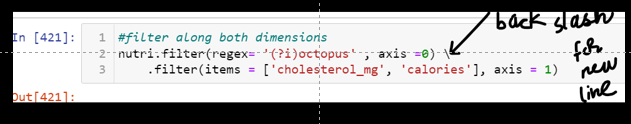

```python
#filter along both dimensions
nutri.filter(regex= '(?i)octopus' , axis =0).filter(items = ['cholesterol_mg', 'calories'], axis = 1)
```

| name | cholesterol_mg | calories |
| --- | --- | --- |
| Octopus (Alaska Native) | 41.0 | 56.0 |
| Mollusks, raw, common, octopus | 48.0 | 82.0 |
| Mollusks, moist heat, cooked, common, octopus | 96.0 | 164.0 |

```python
#we can merge the first code with the loc indexer as well
nutri.filter(regex= '(?i)octopus' , axis = 0).loc[: , ['cholesterol_mg', 'calories']]
```

| name | cholesterol_mg | calories |
| --- | --- | --- |
| Octopus (Alaska Native) | 41.0 | 56.0 |
| Mollusks, raw, common, octopus | 48.0 | 82.0 |
| Mollusks, moist heat, cooked, common, octopus | 96.0 | 164.0 |

### DataFrame Sorting

```python
#lets pick a column from the df nutri
nutri.vitamin_b12_mcg
```

```
name
Cornstarch                                                                                            0.00
Nuts, pecans                                                                                          0.00
Eggplant, raw                                                                                         0.00
Teff, uncooked                                                                                        0.00
Sherbet, orange                                                                                       0.13
                                                                                                      ...
Beef, raw, all grades, trimmed to 0" fat, separable lean and fat, boneless, top round roast, round    1.64
Lamb, cooked, separable lean only, composite of trimmed retail cuts, frozen, imported, New Zealand    2.95
Lamb, raw, separable lean and fat, composite of trimmed retail cuts, frozen, imported, New Zealand    2.42
Beef, raw, all grades, trimmed to 0" fat, separable lean only, boneless, eye of round roast, round    1.84
Beef, raw, all grades, trimmed to 0" fat, separable lean only, boneless, eye of round steak, round    1.84
Name: vitamin_b12_mcg, Length: 8789, dtype: float64
```

```python
#sorting the Series in Ascending order
nutri.vitamin_b12_mcg.sort_values()
```

```
name
Cornstarch                                                                           0.00
Apricots, stewed, sulfured, dehydrated (low-moisture)                                0.00
Cocoa, processed with alkali, unsweetened, dry powder                                0.00
Tomato products, with herbs and cheese, sauce, canned                                0.00
Mothbeans, without salt, boiled, cooked, mature seeds                                0.00
                                                                                    ...
Veal, braised, cooked, liver, variety meats and by-products                         84.60
Lamb, pan-fried, cooked, liver, variety meats and by-products                       85.70
Lamb, raw, liver, variety meats and by-products                                     90.05
Beef, boiled, cooked, variety meats and by-products liver, imported, New Zealand    96.00
Mollusks, moist heat, cooked, mixed species, clam                                   98.89
Name: vitamin_b12_mcg, Length: 8789, dtype: float64
```

```python
cols = nutri.columns
```

```python
#Finding column name
for col in cols:
    if 'b12' in col:
        print(col)
```

```
vitamin_b12_mcg
```

```python
#find column
nutri.filter(like = 'b12' , axis= 1).head(2)
```

| name | vitamin_b12_mcg |
| --- | --- |
| Cornstarch | 0.0 |
| Nuts, pecans | 0.0 |

```python
#Lets sort entire DataFrame
nutri.sort_values()
```

```
---------------------------------------------------------------------------
TypeError                                 Traceback (most recent call last)
<ipython-input-441-ecd9b3bbe9c2> in <module>
      1 #Lets sort entire DataFrame
----> 2 nutri.sort_values()

TypeError: sort_values() missing 1 required positional argument: 'by'
```

- "by" is missing because pandas wants to know the axis . There is uncertainity what you want to sort by.

```python
nutri.sort_values(by = ['calories'] , ascending = False)
```

| name | serving_size_g | calories | total_fat_g | saturated_fat_g | cholesterol_mg | sodium_mg | choline_mg | folate_mcg | folic_acid_mcg | niacin_mg | ... | fat_g | saturated_fatty_acids_g | monounsaturated_fatty_acids_g | polyunsaturated_fatty_acids_g | fatty_acids_total_trans_mg | alcohol_g | ash_g | caffeine_mg | theobromine_mg | water_g |
| --- | --- | --- | --- | --- | --- | --- | --- | --- | --- | --- | --- | --- | --- | --- | --- | --- | --- | --- | --- | --- | --- |
| Fat, mutton tallow | 100.0 | 902.0 | 100.0 | 47.0 | 102.0 | 0.0 | 79.8 | 0.0 | 0.0 | 0.00 | ... | 100.0 | 47.300 | 40.600 | 7.800 | 102.0 | 0.0 | 0.00 | 0.0 | 0.0 | 0.00 |
| Fish oil, salmon | 100.0 | 902.0 | 100.0 | 20.0 | 485.0 | 0.0 | 0.0 | 0.0 | 0.0 | 0.00 | ... | 100.0 | 19.872 | 29.037 | 40.324 | 485.0 | 0.0 | 0.00 | 0.0 | 0.0 | 0.00 |
| Lard | 100.0 | 902.0 | 100.0 | 39.0 | 95.0 | 0.0 | 49.7 | 0.0 | 0.0 | 0.00 | ... | 100.0 | 39.200 | 45.100 | 11.200 | 95.0 | 0.0 | 0.00 | 0.0 | 0.0 | 0.00 |
| Fat, beef tallow | 100.0 | 902.0 | 100.0 | 50.0 | 109.0 | 0.0 | 79.8 | 0.0 | 0.0 | 0.00 | ... | 100.0 | 49.800 | 41.800 | 4.000 | 109.0 | 0.0 | 0.00 | 0.0 | 0.0 | 0.00 |
| Fish oil, cod liver | 100.0 | 902.0 | 100.0 | 23.0 | 570.0 | 0.0 | 0.0 | 0.0 | 0.0 | 0.00 | ... | 100.0 | 22.608 | 46.711 | 22.541 | 570.0 | 0.0 | 0.00 | 0.0 | 0.0 | 0.00 |
| ... | ... | ... | ... | ... | ... | ... | ... | ... | ... | ... | ... | ... | ... | ... | ... | ... | ... | ... | ... | ... | ... |
| Beverages, decaffeinated, brewed, green, tea | 100.0 | 0.0 | 0.0 | NaN | 0.0 | 0.0 | 0.0 | 0.0 | 0.0 | 0.03 | ... | 0.0 | 0.000 | 0.000 | 0.000 | 0.0 | 0.0 | 0.00 | 0.0 | 0.0 | 99.93 |
| Beverages, caffeine free, cola, ZEVIA | 100.0 | 0.0 | 0.0 | NaN | 0.0 | 6.0 | 0.0 | 0.0 | 0.0 | 0.00 | ... | 0.0 | 0.000 | 0.000 | 0.000 | 0.0 | 0.0 | 0.01 | 0.0 | 0.0 | 98.87 |
| Carbonated beverage, without caffeine, with sodium saccharin, other than cola or pepper, low calorie | 100.0 | 0.0 | 0.0 | NaN | 0.0 | 16.0 | 0.0 | 0.0 | 0.0 | 0.00 | ... | 0.0 | 0.000 | 0.000 | 0.000 | 0.0 | 0.0 | 0.10 | 0.0 | 0.0 | 99.80 |
| Beverages, unsweetened, ready to drink, green, tea | 100.0 | 0.0 | 0.0 | NaN | 0.0 | 7.0 | 0.0 | 0.0 | 0.0 | 0.00 | ... | 0.0 | 0.000 | 0.000 | 0.000 | 0.0 | 0.0 | 0.12 | 12.0 | 0.0 | 99.88 |
| Salt, table | 100.0 | 0.0 | 0.0 | NaN | 0.0 | 38758.0 | 0.0 | 0.0 | 0.0 | 0.00 | ... | 0.0 | 0.000 | 0.000 | 0.000 | 0.0 | 0.0 | 99.80 | 0.0 | 0.0 | 0.20 |

8789 rows × 75 columns

- this output doesn't look intuitive, lets sort by cholesterol and sodium and see what foods had most cholesterol and sodium

```python
#We are sorting two columns at once
nutri.sort_values(by = ['cholesterol_mg' , 'sodium_mg'] , ascending = False)
```

| name | serving_size_g | calories | total_fat_g | saturated_fat_g | cholesterol_mg | sodium_mg | choline_mg | folate_mcg | folic_acid_mcg | niacin_mg | ... | fat_g | saturated_fatty_acids_g | monounsaturated_fatty_acids_g | polyunsaturated_fatty_acids_g | fatty_acids_total_trans_mg | alcohol_g | ash_g | caffeine_mg | theobromine_mg | water_g |
| --- | --- | --- | --- | --- | --- | --- | --- | --- | --- | --- | --- | --- | --- | --- | --- | --- | --- | --- | --- | --- | --- |
| Veal, braised, cooked, brain, variety meats and by-products | 100.0 | 136.0 | 9.6 | 2.2 | 3100.0 | 156.0 | 0.0 | 3.0 | 0.0 | 2.430 | ... | 9.63 | 2.180 | 1.740 | 1.490 | 3100.0 | 0.0 | 1.40 | 0.0 | 0.0 | 76.89 |
| Beef, simmered, cooked, brain, variety meats and by-products | 100.0 | 151.0 | 11.0 | 2.4 | 3100.0 | 108.0 | 490.9 | 5.0 | 0.0 | 3.620 | ... | 10.53 | 2.394 | 1.882 | 1.632 | 3100.0 | 0.0 | 1.46 | 0.0 | 0.0 | 74.86 |
| Beef, raw, brain, variety meats and by-products | 100.0 | 143.0 | 10.0 | 2.3 | 3010.0 | 126.0 | 0.0 | 3.0 | 0.0 | 3.550 | ... | 10.30 | 2.300 | 1.890 | 1.586 | 3010.0 | 0.0 | 1.51 | 0.0 | 0.0 | 76.29 |
| Lamb, soaked and fried, cooked, brains, imported, New Zealand | 100.0 | 154.0 | 11.0 | 1.4 | 2559.0 | 101.0 | 0.0 | 0.0 | 0.0 | 2.995 | ... | 10.92 | 1.365 | 4.168 | 0.999 | 2559.0 | 0.0 | 3.39 | 0.0 | 0.0 | 73.11 |
| Pork, braised, cooked, brain, variety meats and by-products, fresh | 100.0 | 138.0 | 9.5 | 2.2 | 2552.0 | 91.0 | 0.0 | 4.0 | 0.0 | 3.330 | ... | 9.51 | 2.150 | 1.720 | 1.470 | 2552.0 | 0.0 | 1.40 | 0.0 | 0.0 | 75.88 |
| ... | ... | ... | ... | ... | ... | ... | ... | ... | ... | ... | ... | ... | ... | ... | ... | ... | ... | ... | ... | ... | ... |
| Oil, principal uses icings and fillings, palm, soy (partially hydrogenated ), industrial | 100.0 | 884.0 | 100.0 | 28.0 | 0.0 | 0.0 | 0.2 | 0.0 | 0.0 | 0.000 | ... | 100.00 | 28.421 | 59.715 | 7.095 | 0.0 | 0.0 | 0.00 | 0.0 | 0.0 | 0.00 |
| Oil, pourable clear fry, soy (partially hydrogenated ) and soy (winterized), industrial | 100.0 | 884.0 | 100.0 | 15.0 | 0.0 | 0.0 | 0.2 | 0.0 | 0.0 | 0.000 | ... | 100.00 | 15.341 | 34.630 | 45.228 | 0.0 | 0.0 | 0.00 | 0.0 | 0.0 | 0.00 |
| Beverages, fortified, Revive Fruit Punch, Glaceau Vitamin Water, The COCA-COLA company | 100.0 | 0.0 | 0.0 | NaN | 0.0 | 0.0 | 0.0 | 0.0 | 0.0 | 3.384 | ... | 0.00 | 0.000 | 0.000 | 0.000 | 0.0 | 0.0 | 0.15 | 0.0 | 0.0 | 99.17 |
| Oil, principal use as a tortilla shortening, soy (partially hydrogenated) and cottonseed, industrial | 100.0 | 884.0 | 100.0 | 26.0 | 0.0 | 0.0 | 0.2 | 0.0 | 0.0 | 0.000 | ... | 100.00 | 25.883 | 59.133 | 10.305 | 0.0 | 0.0 | 0.00 | 0.0 | 0.0 | 0.00 |
| Pan Dulce, contains wheat flour and rice flour, cookie-like, Salpora de Arroz con Azucar, LA RICURA | 100.0 | 445.0 | 16.0 | NaN | 0.0 | 0.0 | 0.0 | 0.0 | 0.0 | 0.000 | ... | 16.11 | 0.000 | 0.000 | 0.000 | 0.0 | 0.0 | 1.68 | 0.0 | 0.0 | 7.12 |

8789 rows × 75 columns

Now that we are working with multiple columns , we also have the option of sorting in multiple directions

```python
#We can sort "cholesterol_mg" in Descending and "sodium_mg" in ascending
```

```python
nutri.sort_values(by = ['cholesterol_mg' , 'sodium_mg'], ascending= [False , True])
```

| name | serving_size_g | calories | total_fat_g | saturated_fat_g | cholesterol_mg | sodium_mg | choline_mg | folate_mcg | folic_acid_mcg | niacin_mg | ... | fat_g | saturated_fatty_acids_g | monounsaturated_fatty_acids_g | polyunsaturated_fatty_acids_g | fatty_acids_total_trans_mg | alcohol_g | ash_g | caffeine_mg | theobromine_mg | water_g |
| --- | --- | --- | --- | --- | --- | --- | --- | --- | --- | --- | --- | --- | --- | --- | --- | --- | --- | --- | --- | --- | --- |
| Beef, simmered, cooked, brain, variety meats and by-products | 100.0 | 151.0 | 11.0 | 2.4 | 3100.0 | 108.0 | 490.9 | 5.0 | 0.0 | 3.620 | ... | 10.53 | 2.394 | 1.882 | 1.632 | 3100.0 | 0.0 | 1.46 | 0.0 | 0.0 | 74.86 |
| Veal, braised, cooked, brain, variety meats and by-products | 100.0 | 136.0 | 9.6 | 2.2 | 3100.0 | 156.0 | 0.0 | 3.0 | 0.0 | 2.430 | ... | 9.63 | 2.180 | 1.740 | 1.490 | 3100.0 | 0.0 | 1.40 | 0.0 | 0.0 | 76.89 |
| Beef, raw, brain, variety meats and by-products | 100.0 | 143.0 | 10.0 | 2.3 | 3010.0 | 126.0 | 0.0 | 3.0 | 0.0 | 3.550 | ... | 10.30 | 2.300 | 1.890 | 1.586 | 3010.0 | 0.0 | 1.51 | 0.0 | 0.0 | 76.29 |
| Lamb, soaked and fried, cooked, brains, imported, New Zealand | 100.0 | 154.0 | 11.0 | 1.4 | 2559.0 | 101.0 | 0.0 | 0.0 | 0.0 | 2.995 | ... | 10.92 | 1.365 | 4.168 | 0.999 | 2559.0 | 0.0 | 3.39 | 0.0 | 0.0 | 73.11 |
| Pork, braised, cooked, brain, variety meats and by-products, fresh | 100.0 | 138.0 | 9.5 | 2.2 | 2552.0 | 91.0 | 0.0 | 4.0 | 0.0 | 3.330 | ... | 9.51 | 2.150 | 1.720 | 1.470 | 2552.0 | 0.0 | 1.40 | 0.0 | 0.0 | 75.88 |
| ... | ... | ... | ... | ... | ... | ... | ... | ... | ... | ... | ... | ... | ... | ... | ... | ... | ... | ... | ... | ... | ... |
| Leavening agents, sodium aluminum sulfate, double-acting, baking powder | 100.0 | 53.0 | 0.0 | NaN | 0.0 | 10600.0 | 0.0 | 0.0 | 0.0 | 0.000 | ... | 0.00 | 0.000 | 0.000 | 0.000 | 0.0 | 0.0 | 67.30 | 0.0 | 0.0 | 5.00 |
| Seasoning mix, coriander & annatto, sazon, dry | 100.0 | 0.0 | 0.0 | NaN | 0.0 | 17000.0 | 0.0 | 0.0 | 0.0 | 0.000 | ... | 0.00 | 0.000 | 0.000 | 0.000 | 0.0 | 0.0 | 99.80 | 0.0 | 0.0 | 0.20 |
| Desserts, unsweetened, tablets, rennin | 100.0 | 84.0 | 0.1 | NaN | 0.0 | 26050.0 | 0.0 | 0.0 | 0.0 | 0.000 | ... | 0.10 | 0.041 | 0.038 | 0.007 | 0.0 | 0.0 | 72.50 | 0.0 | 0.0 | 6.50 |
| Leavening agents, baking soda | 100.0 | 0.0 | 0.0 | NaN | 0.0 | 27360.0 | 0.0 | 0.0 | 0.0 | 0.000 | ... | 0.00 | 0.000 | 0.000 | 0.000 | 0.0 | 0.0 | 36.90 | 0.0 | 0.0 | 0.20 |
| Salt, table | 100.0 | 0.0 | 0.0 | NaN | 0.0 | 38758.0 | 0.0 | 0.0 | 0.0 | 0.000 | ... | 0.00 | 0.000 | 0.000 | 0.000 | 0.0 | 0.0 | 99.80 | 0.0 | 0.0 | 0.20 |

8789 rows × 75 columns

```python
#brain composition detour
#Filter the Index label for only the nutrients expressed in grams
#Lastly sort in Descending order
```

```python
#nutri.iloc[0].filter(like = '_g').sort_values(ascending = False)
#nutri.loc['Beef, simmered, cooked, brain, variety meats and by-products'].filter(like= '_g').sort_values(ascending = False).head(4)
#using "\" for next line

nutri.loc['Beef, simmered, cooked, brain, variety meats and by-products'].filter(like= '_g') \
.sort_values(ascending = False).head(4)
```

```
serving_size_g    100.00
water_g            74.86
protein_g          11.67
total_fat_g        11.00
Name: Beef, simmered, cooked, brain, variety meats and by-products, dtype: float64
```

- The brain is not all fat as people say , it has more protien than fat
- But most of it (almost 75%) of it , is just water

#### Using Series between() with DataFrames

```python
nutri.calories.head(10)
```

```
name
Cornstarch            381.0
Nuts, pecans          691.0
Eggplant, raw          25.0
Teff, uncooked        367.0
Sherbet, orange       144.0
Cauliflower, raw       25.0
Taro leaves, raw       42.0
Lamb, raw, ground     282.0
Cheese, camembert     300.0
Vegetarian fillets    290.0
Name: calories, dtype: float64
```

```python
nutri.calories.between(20 , 60)  #we get a series of booleans
```

```
name
Cornstarch                                                                                            False
Nuts, pecans                                                                                          False
Eggplant, raw                                                                                          True
Teff, uncooked                                                                                        False
Sherbet, orange                                                                                       False
                                                                                                      ...
Beef, raw, all grades, trimmed to 0" fat, separable lean and fat, boneless, top round roast, round    False
Lamb, cooked, separable lean only, composite of trimmed retail cuts, frozen, imported, New Zealand    False
Lamb, raw, separable lean and fat, composite of trimmed retail cuts, frozen, imported, New Zealand    False
Beef, raw, all grades, trimmed to 0" fat, separable lean only, boneless, eye of round roast, round    False
Beef, raw, all grades, trimmed to 0" fat, separable lean only, boneless, eye of round steak, round    False
Name: calories, Length: 8789, dtype: bool
```

```python
nutri[nutri.calories.between(20 , 60)]
```

| name | serving_size_g | calories | total_fat_g | saturated_fat_g | cholesterol_mg | sodium_mg | choline_mg | folate_mcg | folic_acid_mcg | niacin_mg | ... | fat_g | saturated_fatty_acids_g | monounsaturated_fatty_acids_g | polyunsaturated_fatty_acids_g | fatty_acids_total_trans_mg | alcohol_g | ash_g | caffeine_mg | theobromine_mg | water_g |
| --- | --- | --- | --- | --- | --- | --- | --- | --- | --- | --- | --- | --- | --- | --- | --- | --- | --- | --- | --- | --- | --- |
| Eggplant, raw | 100.0 | 25.0 | 0.2 | NaN | 0.0 | 2.0 | 6.9 | 22.0 | 0.0 | 0.649 | ... | 0.18 | 0.034 | 0.016 | 0.076 | 0.0 | 0.0 | 0.66 | 0.0 | 0.0 | 92.30 |
| Cauliflower, raw | 100.0 | 25.0 | 0.3 | 0.1 | 0.0 | 30.0 | 44.3 | 57.0 | 0.0 | 0.507 | ... | 0.28 | 0.130 | 0.034 | 0.031 | 0.0 | 0.0 | 0.76 | 0.0 | 0.0 | 92.07 |
| Taro leaves, raw | 100.0 | 42.0 | 0.7 | 0.2 | 0.0 | 3.0 | 12.8 | 126.0 | 0.0 | 1.513 | ... | 0.74 | 0.151 | 0.060 | 0.307 | 0.0 | 0.0 | 1.92 | 0.0 | 0.0 | 85.66 |
| PACE, Picante Sauce | 100.0 | 25.0 | 0.0 | NaN | 0.0 | 781.0 | 0.0 | 0.0 | 0.0 | 0.000 | ... | 0.00 | 0.000 | 0.000 | 0.000 | 0.0 | 0.0 | 3.85 | 0.0 | 0.0 | 89.90 |
| Mango nectar, canned | 100.0 | 51.0 | 0.1 | NaN | 0.0 | 5.0 | 1.5 | 7.0 | 0.0 | 0.080 | ... | 0.06 | 0.014 | 0.022 | 0.011 | 0.0 | 0.0 | 0.08 | 0.0 | 0.0 | 86.63 |
| ... | ... | ... | ... | ... | ... | ... | ... | ... | ... | ... | ... | ... | ... | ... | ... | ... | ... | ... | ... | ... | ... |
| Beverages, added calcium, high vitamin C, greater than 3% fruit juice, reduced sugar, Fruit flavored drink | 100.0 | 29.0 | 0.4 | NaN | 0.0 | 25.0 | 0.1 | 2.0 | 0.0 | 0.000 | ... | 0.37 | 0.000 | 0.000 | 0.000 | 0.0 | 0.0 | 0.06 | 0.0 | 0.0 | 93.00 |
| Ruby Red grapefruit juice blend (grapefruit, grape, apple), with added vitamin C, bottled, OCEAN SPRAY | 100.0 | 44.0 | 0.1 | NaN | 0.0 | 8.0 | 0.0 | 0.0 | 0.0 | 0.000 | ... | 0.10 | 0.008 | 0.008 | 0.014 | 0.0 | 0.0 | 0.27 | 0.0 | 0.0 | 88.60 |
| Beverages, prepared with water, frozen concentrate, with juice and pulp, breakfast type, Orange drink | 100.0 | 45.0 | 0.0 | NaN | 0.0 | 10.0 | 0.0 | 0.0 | 0.0 | 0.253 | ... | 0.00 | 0.001 | 0.001 | 0.001 | 0.0 | 0.0 | 0.48 | 0.0 | 0.0 | 88.08 |
| Apple juice, diluted with 3 volume water without added ascorbic acid, unsweetened, frozen concentrate | 100.0 | 47.0 | 0.1 | NaN | 0.0 | 7.0 | 1.8 | 0.0 | 0.0 | 0.038 | ... | 0.10 | 0.018 | 0.002 | 0.031 | 0.0 | 0.0 | 0.32 | 0.0 | 0.0 | 87.90 |
| Apple juice, with added ascorbic acid, diluted with 3 volume water, unsweetened, frozen concentrate | 100.0 | 47.0 | 0.1 | NaN | 0.0 | 7.0 | 0.0 | 0.0 | 0.0 | 0.038 | ... | 0.10 | 0.018 | 0.002 | 0.031 | 0.0 | 0.0 | 0.32 | 0.0 | 0.0 | 87.90 |

1190 rows × 75 columns

### This is a combination of Series Boolean mask and Dataframe indexing

```python
#lets just get a random sample of 4 records
nutri[nutri.calories.between(20 , 60)].sample(4)
```

| name | serving_size_g | calories | total_fat_g | saturated_fat_g | cholesterol_mg | sodium_mg | choline_mg | folate_mcg | folic_acid_mcg | niacin_mg | ... | fat_g | saturated_fatty_acids_g | monounsaturated_fatty_acids_g | polyunsaturated_fatty_acids_g | fatty_acids_total_trans_mg | alcohol_g | ash_g | caffeine_mg | theobromine_mg | water_g |
| --- | --- | --- | --- | --- | --- | --- | --- | --- | --- | --- | --- | --- | --- | --- | --- | --- | --- | --- | --- | --- | --- |
| Mammy-apple, raw, (mamey) | 100.0 | 51.0 | 0.5 | 0.1 | 0.0 | 15.0 | 0.0 | 14.0 | 0.0 | 0.40 | ... | 0.50 | 0.136 | 0.205 | 0.079 | 0.0 | 0.0 | 0.30 | 0.0 | 0.0 | 86.20 |
| Babyfood, strained, carrots and beef | 100.0 | 59.0 | 2.5 | 1.0 | 8.0 | 69.0 | 15.9 | 17.0 | 0.0 | 0.93 | ... | 2.50 | 0.960 | 1.060 | 0.130 | 8.0 | 0.0 | 0.70 | 0.0 | 0.0 | 87.30 |
| CAMPBELL'S Red and White, condensed, Beef Noodle Soup | 100.0 | 56.0 | 1.6 | 0.4 | 8.0 | 651.0 | 0.0 | 0.0 | 0.0 | 0.00 | ... | 1.59 | 0.397 | 0.397 | 0.794 | 8.0 | 0.0 | 3.69 | 0.0 | 0.0 | 85.20 |
| SILK Plus Omega-3 DHA, soymilk | 100.0 | 45.0 | 2.1 | 0.2 | 0.0 | 49.0 | 0.0 | 10.0 | 0.0 | 0.00 | ... | 2.06 | 0.206 | 0.000 | 0.000 | 0.0 | 0.0 | 0.64 | 0.0 | 0.0 | 91.13 |

4 rows × 75 columns

### min() , max() and idx[MinMax]

We can use these functions on the columns as well as on the Rows

- We can find the min and max of columns as well as the rows

```python
#default is column wise
nutri.min()
```

```
serving_size_g     100.0
calories             0.0
total_fat_g          0.0
saturated_fat_g      0.1
cholesterol_mg       0.0
                   ...
alcohol_g            0.0
ash_g                0.0
caffeine_mg          0.0
theobromine_mg       0.0
water_g              0.0
Length: 75, dtype: float64
```

```python
#To get the row-wise , just pass the axis parameter
nutri.min(axis = 1)
```

```
name
Cornstarch                                                                                            0.0
Nuts, pecans                                                                                          0.0
Eggplant, raw                                                                                         0.0
Teff, uncooked                                                                                        0.0
Sherbet, orange                                                                                       0.0
                                                                                                     ...
Beef, raw, all grades, trimmed to 0" fat, separable lean and fat, boneless, top round roast, round    0.0
Lamb, cooked, separable lean only, composite of trimmed retail cuts, frozen, imported, New Zealand    0.0
Lamb, raw, separable lean and fat, composite of trimmed retail cuts, frozen, imported, New Zealand    0.0
Beef, raw, all grades, trimmed to 0" fat, separable lean only, boneless, eye of round roast, round    0.0
Beef, raw, all grades, trimmed to 0" fat, separable lean only, boneless, eye of round steak, round    0.0
Length: 8789, dtype: float64
```

### What food has the most potassium

```python
#Finding the column name
nutri.filter(like = 'potassium' , axis = 1)
```

| name | potassium_mg |
| --- | --- |
| Cornstarch | 3.0 |
| Nuts, pecans | 410.0 |
| Eggplant, raw | 229.0 |
| Teff, uncooked | 427.0 |
| Sherbet, orange | 96.0 |
| ... | ... |
| Beef, raw, all grades, trimmed to 0" fat, separable lean and fat, boneless, top round roast, round | 311.0 |
| Lamb, cooked, separable lean only, composite of trimmed retail cuts, frozen, imported, New Zealand | 188.0 |
| Lamb, raw, separable lean and fat, composite of trimmed retail cuts, frozen, imported, New Zealand | 136.0 |
| Beef, raw, all grades, trimmed to 0" fat, separable lean only, boneless, eye of round roast, round | 319.0 |
| Beef, raw, all grades, trimmed to 0" fat, separable lean only, boneless, eye of round steak, round | 319.0 |

8789 rows × 1 columns

```python
nutri['potassium_mg'].max()
```

```
16500.0
```

- So, Potassium is measured in milligrams and that is 16 and a half grams of potassium in a 100 gram serving
- if you look at the "serving_size_g" column , you will notice that the Serving size is 100 g

```python
nutri.loc[nutri['potassium_mg'] == nutri['potassium_mg'].max()]
```

| name | serving_size_g | calories | total_fat_g | saturated_fat_g | cholesterol_mg | sodium_mg | choline_mg | folate_mcg | folic_acid_mcg | niacin_mg | ... | fat_g | saturated_fatty_acids_g | monounsaturated_fatty_acids_g | polyunsaturated_fatty_acids_g | fatty_acids_total_trans_mg | alcohol_g | ash_g | caffeine_mg | theobromine_mg | water_g |
| --- | --- | --- | --- | --- | --- | --- | --- | --- | --- | --- | --- | --- | --- | --- | --- | --- | --- | --- | --- | --- | --- |
| Leavening agents, cream of tartar | 100.0 | 258.0 | 0.0 | NaN | 0.0 | 52.0 | 0.0 | 0.0 | 0.0 | 0.0 | ... | 0.0 | 0.0 | 0.0 | 0.0 | 0.0 | 0.0 | 36.8 | 0.0 | 0.0 | 1.7 |

1 rows × 75 columns

### idx method to get the label associated with the maximum value

```python
#Or we can use the idx method to get the label associated with the maximum value
nutri.potassium_mg.idxmax()
```

```
'Leavening agents, cream of tartar'
```

- This is not the kind of food you would have a 100 gm in one sitting
- Lets look at couple more values

#### Facts about Sodium and Potassium for Good Health :

With few exceptions, a healthier diet should be lower in sodium and higher in potassium.

a healthier diet should be lower in sodium and higher in potassium.

In fact, lowering dietary sodium intake and increasing potassium intake (resulting in a lower sodium potassium ratio) is an integral strategy of national and international public health goals.

Thus, a diet with high quality produces a low sodium potassium ratio (generally less than the number 1)

Over 70% of our sodium intake is derived from packaged, preprepared, or restaurant foods

To calculate the sodium to potassium ratio, simply divide the amount of sodium by the amount of potassium

```python
16500 / 1000
```

```
16.5
```

```python
nutri.potassium_mg.sort_values(ascending = False).head(10)
```

```
name
Leavening agents, cream of tartar                         16500.0
Leavening agents, low-sodium, baking powder               10100.0
Parsley, freeze-dried                                      6300.0
Beverages, powder, unsweetened, instant, tea               6040.0
Beverages, unsweetened, decaffeinated, instant, tea        6040.0
Spices, dried, chervil                                     4740.0
Spices, dried, coriander leaf                              4466.0
Celery flakes, dried                                       4388.0
Beverages, half the caffeine, regular, instant, coffee     3535.0
Beverages, powder, regular, instant, coffee                3535.0
Name: potassium_mg, dtype: float64
```

- Its said that Potassium is in relation to sodium in a diet
- Lets analyze further

We are looking for food Items with Sodium to Potassium Ratio of roughly 1 : 16

```python
#Lets create a Series by dividing the Potassium column by Sodium
#K : Potassium , Na is sodium
```

```python
K_to_NA = (nutri.potassium_mg / nutri.sodium_mg)
```

In order to avoid division by 0 , we will replace all zeros with ones in the whole series

```python
K_to_NA = (nutri.potassium_mg.replace(0,1) / nutri.sodium_mg.replace(0,1))
```

### Potassium to Sodium RATIO

```python
#Lets also sort this series in Descending order
K_to_NA = (nutri.potassium_mg.replace(0,1) / nutri.sodium_mg.replace(0,1)).sort_values(ascending = False)
```

```python
K_to_NA.head(15)
```

```
name
Peanut flour, low fat                                           1358.0
Nuts, raw, pistachio nuts                                       1025.0
Beverages, reduced calorie, with whitener, instant, coffee       909.0
Soybeans, raw, mature seeds                                      898.5
Soy meal, raw, defatted                                          830.0
Babyfood, dry, with bananas, rice, cereal                        769.0
Nuts, without salt added, dry roasted, hazelnuts or filberts     755.0
Soy protein concentrate, produced by alcohol extraction          734.0
Nuts, almonds                                                    733.0
Nuts, full fat, acorn flour                                      712.0
Nuts, dried, acorns                                              709.0
Nuts, without salt added, oil roasted, almonds                   699.0
Dates, medjool                                                   696.0
Soybeans, dry roasted, mature seeds                              682.0
Nuts, hazelnuts or filberts                                      680.0
dtype: float64
```

- So, it appears that Nuts and Soy have a lot of relative potassium compared to Sodium.

#### Looking at Foods with Potassium to sodium Ratio between 14 and 18

```python
K_to_NA[K_to_NA.between(14 , 18)].sample(10)
```

```
name
Vinegar, cider                                                                                                     14.600000
Juice, with added ascorbic acid and calcium, grape and pear blend, apple                                           17.800000
Cherries, solids and liquids (includes USDA commodity red tart cherries, canned), water pack, canned, red, sour    14.000000
Fruit cocktail, solids and liquids, light syrup, canned, (peach and pineapple and pear and grape and cherry)       14.833333
Babyfood, strained, papaya and applesauce with tapioca, fruit                                                      15.800000
Fruit cocktail, solids and liquids, heavy syrup, canned, (peach and pineapple and pear and grape and cherry)       14.666667
Mustard greens, without salt, drained, boiled, cooked                                                              18.000000
Fish, raw, wild, rainbow, trout                                                                                    15.516129
Peppers, without salt, drained, boiled, chopped, frozen, green, sweet                                              18.000000
Fish, dry heat, cooked, spot                                                                                       17.189189
dtype: float64
```

https://www.udemy.com/course/the-ultimate-pandas-bootcamp-advanced-python-data-analysis/learn/lecture/18700634#overview

### DataFrame nlargest() and nsmallest()

In the above exercise , we looked at the foods with highest potassium content.

- We did this in two steps, we first sorted the series, then we got the first 10 items using the head method.
- Its worth knowing , that for this exact purpose of getting the largest "x" values and their labels, we could also use a method that we discussed before . That is the nlargest() method.

```python
nutri.nlargest(10 , columns = 'potassium_mg')
```

| name | serving_size_g | calories | total_fat_g | saturated_fat_g | cholesterol_mg | sodium_mg | choline_mg | folate_mcg | folic_acid_mcg | niacin_mg | ... | fat_g | saturated_fatty_acids_g | monounsaturated_fatty_acids_g | polyunsaturated_fatty_acids_g | fatty_acids_total_trans_mg | alcohol_g | ash_g | caffeine_mg | theobromine_mg | water_g |
| --- | --- | --- | --- | --- | --- | --- | --- | --- | --- | --- | --- | --- | --- | --- | --- | --- | --- | --- | --- | --- | --- |
| Leavening agents, cream of tartar | 100.0 | 258.0 | 0.0 | NaN | 0.0 | 52.0 | 0.0 | 0.0 | 0.0 | 0.000 | ... | 0.00 | 0.000 | 0.000 | 0.000 | 0.0 | 0.0 | 36.80 | 0.0 | 0.0 | 1.70 |
| Leavening agents, low-sodium, baking powder | 100.0 | 97.0 | 0.4 | 0.1 | 0.0 | 90.0 | 0.0 | 0.0 | 0.0 | 0.000 | ... | 0.40 | 0.073 | 0.006 | 0.121 | 0.0 | 0.0 | 46.40 | 0.0 | 0.0 | 6.20 |
| Parsley, freeze-dried | 100.0 | 271.0 | 5.2 | NaN | 0.0 | 391.0 | 0.0 | 194.0 | 0.0 | 10.400 | ... | 5.20 | 0.000 | 0.000 | 0.000 | 0.0 | 0.0 | 19.12 | 0.0 | 0.0 | 2.00 |
| Beverages, powder, unsweetened, instant, tea | 100.0 | 315.0 | 0.0 | NaN | 0.0 | 72.0 | 118.3 | 103.0 | 0.0 | 10.800 | ... | 0.00 | 0.000 | 0.000 | 0.000 | 0.0 | 0.0 | 16.04 | 5714.0 | 71.0 | 5.09 |
| Beverages, unsweetened, decaffeinated, instant, tea | 100.0 | 315.0 | 0.0 | NaN | 0.0 | 72.0 | 118.3 | 103.0 | 0.0 | 10.800 | ... | 0.00 | 0.000 | 0.000 | 0.000 | 0.0 | 0.0 | 16.04 | 169.0 | 11.0 | 5.09 |
| Spices, dried, chervil | 100.0 | 237.0 | 3.9 | 0.2 | 0.0 | 83.0 | 0.0 | 274.0 | 0.0 | 5.400 | ... | 3.90 | 0.169 | 1.399 | 1.800 | 0.0 | 0.0 | 16.60 | 0.0 | 0.0 | 7.20 |
| Spices, dried, coriander leaf | 100.0 | 279.0 | 4.8 | 0.1 | 0.0 | 211.0 | 97.1 | 274.0 | 0.0 | 10.707 | ... | 4.78 | 0.115 | 2.232 | 0.328 | 0.0 | 0.0 | 14.08 | 0.0 | 0.0 | 7.30 |
| Celery flakes, dried | 100.0 | 319.0 | 2.1 | 0.6 | 0.0 | 1435.0 | 122.3 | 107.0 | 0.0 | 4.640 | ... | 2.10 | 0.555 | 0.405 | 1.035 | 0.0 | 0.0 | 13.90 | 0.0 | 0.0 | 9.00 |
| Beverages, powder, regular, instant, coffee | 100.0 | 353.0 | 0.5 | 0.2 | 0.0 | 37.0 | 101.9 | 0.0 | 0.0 | 28.173 | ... | 0.50 | 0.197 | 0.041 | 0.196 | 0.0 | 0.0 | 8.80 | 3142.0 | 0.0 | 3.10 |
| Beverages, half the caffeine, regular, instant, coffee | 100.0 | 352.0 | 0.5 | 0.2 | 0.0 | 37.0 | 101.9 | 0.0 | 0.0 | 28.173 | ... | 0.50 | 0.197 | 0.041 | 0.196 | 0.0 | 0.0 | 8.80 | 1571.0 | 0.0 | 3.10 |

10 rows × 75 columns

- We got the nlargest : potassium_mg but above we are looking at a slice of DataFrame with all the columns
- To restrict it to just one column we could either use "." accessor or .loc

```python
#nutri.nlargest(10 ,columns = 'potassium_mg').potassium_mg
nutri.potassium_mg.nlargest(10)
```

```
name
Leavening agents, cream of tartar                         16500.0
Leavening agents, low-sodium, baking powder               10100.0
Parsley, freeze-dried                                      6300.0
Beverages, powder, unsweetened, instant, tea               6040.0
Beverages, unsweetened, decaffeinated, instant, tea        6040.0
Spices, dried, chervil                                     4740.0
Spices, dried, coriander leaf                              4466.0
Celery flakes, dried                                       4388.0
Beverages, powder, regular, instant, coffee                3535.0
Beverages, half the caffeine, regular, instant, coffee     3535.0
Name: potassium_mg, dtype: float64
```

```python
#nsmallest()
nutri.sodium_mg.nsmallest(10)
```

```
name
Nuts, pecans              0.0
PACE, Green Taco Sauce    0.0
Oil, soybean lecithin     0.0
Syrup, fruit flavored     0.0
Oranges, Florida, raw     0.0
Cherries, raw, sweet      0.0
Peaches, raw, yellow      0.0
Oil, corn and canola      0.0
Game meat, raw, bear      0.0
Oil, ucuhuba butter       0.0
Name: sodium_mg, dtype: float64
```

#### Instead of passing a single label , we can also pass a List of labels

```python
#To figure out 10 smallest observations , first "Order by"  : "sodium_mg" and then "Order by" : "Calories"
#and then order by : "folate_mg"
#This is kind of multi-column Sorting
```

```python
#nutri.nsmallest(10 , columns = ['sodium_mg' , 'calories' , 'folate_mcg'])
nutri.nsmallest(10 , ['sodium_mg' , 'calories' , 'folate_mcg'])
```

| name | serving_size_g | calories | total_fat_g | saturated_fat_g | cholesterol_mg | sodium_mg | choline_mg | folate_mcg | folic_acid_mcg | niacin_mg | ... | fat_g | saturated_fatty_acids_g | monounsaturated_fatty_acids_g | polyunsaturated_fatty_acids_g | fatty_acids_total_trans_mg | alcohol_g | ash_g | caffeine_mg | theobromine_mg | water_g |
| --- | --- | --- | --- | --- | --- | --- | --- | --- | --- | --- | --- | --- | --- | --- | --- | --- | --- | --- | --- | --- | --- |
| Beverages, well, tap, water | 100.0 | 0.0 | 0.0 | NaN | 0.0 | 0.0 | 0.0 | 0.0 | 0.0 | 0.00 | ... | 0.0 | 0.0 | 0.0 | 0.0 | 0.0 | 0.0 | 0.10 | 0.0 | 0.0 | 99.90 |
| Water, NAYA, non-carbonated, bottled | 100.0 | 0.0 | 0.0 | NaN | 0.0 | 0.0 | 0.0 | 0.0 | 0.0 | 0.00 | ... | 0.0 | 0.0 | 0.0 | 0.0 | 0.0 | 0.0 | 0.10 | 0.0 | 0.0 | 100.00 |
| Beverages, decaffeinated, brewed, green, tea | 100.0 | 0.0 | 0.0 | NaN | 0.0 | 0.0 | 0.0 | 0.0 | 0.0 | 0.03 | ... | 0.0 | 0.0 | 0.0 | 0.0 | 0.0 | 0.0 | 0.00 | 0.0 | 0.0 | 99.93 |
| Beverages, EVIAN, non-carbonated, bottled, water | 100.0 | 0.0 | 0.0 | NaN | 0.0 | 0.0 | 0.0 | 0.0 | 0.0 | 0.00 | ... | 0.0 | 0.0 | 0.0 | 0.0 | 0.0 | 0.0 | 0.05 | 0.0 | 0.0 | 99.97 |
| Beverages, CALISTOGA, non-carbonated, bottled, water | 100.0 | 0.0 | 0.0 | NaN | 0.0 | 0.0 | 0.0 | 0.0 | 0.0 | 0.00 | ... | 0.0 | 0.0 | 0.0 | 0.0 | 0.0 | 0.0 | 0.10 | 0.0 | 0.0 | 100.00 |
| Beverages, DANNON, non-carbonated, bottled, water | 100.0 | 0.0 | 0.0 | NaN | 0.0 | 0.0 | 0.0 | 0.0 | 0.0 | 0.00 | ... | 0.0 | 0.0 | 0.0 | 0.0 | 0.0 | 0.0 | 0.00 | 0.0 | 0.0 | 99.98 |
| Sweetener, herbal extract powder from Stevia leaf | 100.0 | 0.0 | 0.0 | NaN | 0.0 | 0.0 | 0.0 | 0.0 | 0.0 | 0.00 | ... | 0.0 | 0.0 | 0.0 | 0.0 | 0.0 | 0.0 | 0.00 | 0.0 | 0.0 | 0.00 |
| Beverages, CRYSTAL GEYSER, non-carbonated, bottled, water | 100.0 | 0.0 | 0.0 | NaN | 0.0 | 0.0 | 0.0 | 0.0 | 0.0 | 0.00 | ... | 0.0 | 0.0 | 0.0 | 0.0 | 0.0 | 0.0 | 0.10 | 0.0 | 0.0 | 100.00 |
| Babyfood, without added fluoride., GERBER, bottled, water | 100.0 | 0.0 | 0.0 | NaN | 0.0 | 0.0 | 0.0 | 0.0 | 0.0 | 0.00 | ... | 0.0 | 0.0 | 0.0 | 0.0 | 0.0 | 0.0 | 0.00 | 0.0 | 0.0 | 99.90 |
| Beverages, AQUAFINA, PEPSI, non-carbonated, bottled, water | 100.0 | 0.0 | 0.0 | NaN | 0.0 | 0.0 | 0.0 | 0.0 | 0.0 | 0.00 | ... | 0.0 | 0.0 | 0.0 | 0.0 | 0.0 | 0.0 | 0.00 | 0.0 | 0.0 | 99.97 |

10 rows × 75 columns

### Skill Challenge

#### Find the 10 foods that have most Vitamin B12. What do they have in common?

```python
#Lets check the column name first
nutri.filter(like = 'b12').head(1)
```

| name | vitamin_b12_mcg |
| --- | --- |
| Cornstarch | 0.0 |

```python
nutri.vitamin_b12_mcg.nlargest(10)
```

```
name
Mollusks, moist heat, cooked, mixed species, clam                                   98.89
Beef, boiled, cooked, variety meats and by-products liver, imported, New Zealand    96.00
Lamb, raw, liver, variety meats and by-products                                     90.05
Lamb, pan-fried, cooked, liver, variety meats and by-products                       85.70
Veal, braised, cooked, liver, variety meats and by-products                         84.60
Beef, raw, liver, variety meats and by-products, imported, New Zealand              84.50
Beef, pan-fried, cooked, liver, variety meats and by-products                       83.13
Lamb, braised, cooked, kidneys, variety meats and by-products                       78.90
Lamb, braised, cooked, liver, variety meats and by-products                         76.50
Veal, pan-fried, cooked, liver, variety meats and by-products                       72.50
Name: vitamin_b12_mcg, dtype: float64
```

- These are mostly non-veg food items

#### Isolate the foods in the Dataset that contain, or are based on eggplant, which of them has the most sodium?

```python
nutri.filter(regex='[eE]ggplant' , axis = 0)
```

| name | serving_size_g | calories | total_fat_g | saturated_fat_g | cholesterol_mg | sodium_mg | choline_mg | folate_mcg | folic_acid_mcg | niacin_mg | ... | fat_g | saturated_fatty_acids_g | monounsaturated_fatty_acids_g | polyunsaturated_fatty_acids_g | fatty_acids_total_trans_mg | alcohol_g | ash_g | caffeine_mg | theobromine_mg | water_g |
| --- | --- | --- | --- | --- | --- | --- | --- | --- | --- | --- | --- | --- | --- | --- | --- | --- | --- | --- | --- | --- | --- |
| Eggplant, raw | 100.0 | 25.0 | 0.2 | NaN | 0.0 | 2.0 | 6.9 | 22.0 | 0.0 | 0.649 | ... | 0.18 | 0.034 | 0.016 | 0.076 | 0.0 | 0.0 | 0.66 | 0.0 | 0.0 | 92.30 |
| Eggplant, pickled | 100.0 | 49.0 | 0.7 | 0.1 | 0.0 | 1674.0 | 11.9 | 20.0 | 0.0 | 0.660 | ... | 0.70 | 0.140 | 0.063 | 0.294 | 0.0 | 0.0 | 1.73 | 0.0 | 0.0 | 86.90 |
| Eggplant, with salt, drained, boiled, cooked | 100.0 | 33.0 | 0.2 | NaN | 0.0 | 239.0 | 9.4 | 14.0 | 0.0 | 0.600 | ... | 0.23 | 0.044 | 0.020 | 0.093 | 0.0 | 0.0 | 1.13 | 0.0 | 0.0 | 89.67 |
| Eggplant, without salt, drained, boiled, cooked | 100.0 | 35.0 | 0.2 | NaN | 0.0 | 1.0 | 9.4 | 14.0 | 0.0 | 0.600 | ... | 0.23 | 0.044 | 0.020 | 0.093 | 0.0 | 0.0 | 0.54 | 0.0 | 0.0 | 89.67 |

4 rows × 75 columns

```python
nutri.filter(regex='[eE]ggplant' , axis = 0).sodium_mg.max()
```

```
1674.0
```

```python
eggplant = nutri.filter(regex='[eE]ggplant' , axis = 0)
```

```python
eggplant.loc[eggplant.sodium_mg == eggplant.sodium_mg.max()]
```

| name | serving_size_g | calories | total_fat_g | saturated_fat_g | cholesterol_mg | sodium_mg | choline_mg | folate_mcg | folic_acid_mcg | niacin_mg | ... | fat_g | saturated_fatty_acids_g | monounsaturated_fatty_acids_g | polyunsaturated_fatty_acids_g | fatty_acids_total_trans_mg | alcohol_g | ash_g | caffeine_mg | theobromine_mg | water_g |
| --- | --- | --- | --- | --- | --- | --- | --- | --- | --- | --- | --- | --- | --- | --- | --- | --- | --- | --- | --- | --- | --- |
| Eggplant, pickled | 100.0 | 49.0 | 0.7 | 0.1 | 0.0 | 1674.0 | 11.9 | 20.0 | 0.0 | 0.66 | ... | 0.7 | 0.14 | 0.063 | 0.294 | 0.0 | 0.0 | 1.73 | 0.0 | 0.0 | 86.9 |

1 rows × 75 columns

```python
eggplant.sodium_mg.idxmax()
```

```
'Eggplant, pickled'
```

### Select a Slice of the DataFrame that contains 4 random rows and 2 random columns

```python
#Selecting random rows
#Selecting random columns : ".sample(2 , axis = 1)"
nutri.sample(4).sample(2, axis = 1)
```

| name | fatty_acids_total_trans_mg | glutamic_acid_g |
| --- | --- | --- |
| Beef, grilled, cooked, all grades, trimmed to 0" fat, separable lean only, lip off, boneless, rib eye steak | 79.0 | 5.011 |
| Fish, dry heat, cooked, sheepshead | 64.0 | 3.884 |
| Beef, roasted, cooked, select, trimmed to 1/8" fat, separable lean only, roast, bottom round , round | 74.0 | 4.271 |
| Peppers, raw, serrano | 0.0 | 0.000 |

```python
#Selecting 2 random columns
nutri.sample(2, axis = 1)
```

| name | vitamin_c_mg | protein_g |
| --- | --- | --- |
| Cornstarch | 0.0 | 0.26 |
| Nuts, pecans | 1.1 | 9.17 |
| Eggplant, raw | 2.2 | 0.98 |
| Teff, uncooked | 0.0 | 13.30 |
| Sherbet, orange | 2.3 | 1.10 |
| ... | ... | ... |
| Beef, raw, all grades, trimmed to 0" fat, separable lean and fat, boneless, top round roast, round | 0.0 | 23.45 |
| Lamb, cooked, separable lean only, composite of trimmed retail cuts, frozen, imported, New Zealand | 0.0 | 29.59 |
| Lamb, raw, separable lean and fat, composite of trimmed retail cuts, frozen, imported, New Zealand | 0.0 | 16.74 |
| Beef, raw, all grades, trimmed to 0" fat, separable lean only, boneless, eye of round roast, round | 0.0 | 23.37 |
| Beef, raw, all grades, trimmed to 0" fat, separable lean only, boneless, eye of round steak, round | 0.0 | 23.37 |

8789 rows × 2 columns

#### Remove all the food items that contain atleast one NaN.Do this in a way that modifies the DataFrame. i.e, the changes stick. How many food items remain after the exclusion?

```python
nutri2 = nutri.copy()
```

```python
#nutri.dropna(axis = 0 ,how = any , inplace = True)
```

```python
nutri.dropna(inplace = True)
```

```python
nutri.shape
```

```
(7199, 75)
```

#### From the remaining records , isolate those that have between 20 to 40 mg of Vitamin C per 100 g serving. Of these foods which one is the least caloric, i.e has the minimum calories?

```python
#finding the column name
nutri.filter(like = 'vitamin' , axis = 1).head(1)
```

| name | vitamin_a_IU | vitamin_a_rae_mcg | vitamin_b12_mcg | vitamin_b6_mg | vitamin_c_mg | vitamin_d_IU | vitamin_e_mg | vitamin_k_mcg |
| --- | --- | --- | --- | --- | --- | --- | --- | --- |
| Nuts, pecans | 56.0 | 3.0 | 0.0 | 0.21 | 1.1 | 0.0 | 1.4 | 3.5 |

```python
#vitamin_c_mg
nutri.vitamin_c_mg.between(20 , 40)
```

```
name
Nuts, pecans                                                                                          False
Teff, uncooked                                                                                        False
Sherbet, orange                                                                                       False
Cauliflower, raw                                                                                      False
Taro leaves, raw                                                                                      False
                                                                                                      ...
Beef, raw, all grades, trimmed to 0" fat, separable lean and fat, boneless, top round roast, round    False
Lamb, cooked, separable lean only, composite of trimmed retail cuts, frozen, imported, New Zealand    False
Lamb, raw, separable lean and fat, composite of trimmed retail cuts, frozen, imported, New Zealand    False
Beef, raw, all grades, trimmed to 0" fat, separable lean only, boneless, eye of round roast, round    False
Beef, raw, all grades, trimmed to 0" fat, separable lean only, boneless, eye of round steak, round    False
Name: vitamin_c_mg, Length: 7199, dtype: bool
```

```python
nutri.loc[nutri.vitamin_c_mg.between(20 , 40)]
```

| name | serving_size_g | calories | total_fat_g | saturated_fat_g | cholesterol_mg | sodium_mg | choline_mg | folate_mcg | folic_acid_mcg | niacin_mg | ... | fat_g | saturated_fatty_acids_g | monounsaturated_fatty_acids_g | polyunsaturated_fatty_acids_g | fatty_acids_total_trans_mg | alcohol_g | ash_g | caffeine_mg | theobromine_mg | water_g |
| --- | --- | --- | --- | --- | --- | --- | --- | --- | --- | --- | --- | --- | --- | --- | --- | --- | --- | --- | --- | --- | --- |
| Broccoli, raw, chinese | 100.0 | 30.0 | 0.8 | 0.1 | 0.0 | 7.0 | 26.5 | 104.0 | 0.0 | 0.459 | ... | 0.76 | 0.116 | 0.053 | 0.347 | 0.0 | 0.0 | 0.83 | 0.0 | 0.0 | 92.55 |
| Broccoli raab, cooked | 100.0 | 33.0 | 0.5 | 0.1 | 0.0 | 56.0 | 33.6 | 71.0 | 0.0 | 2.015 | ... | 0.52 | 0.057 | 0.030 | 0.150 | 0.0 | 0.0 | 1.11 | 0.0 | 0.0 | 91.41 |
| Horseradish, prepared | 100.0 | 48.0 | 0.7 | 0.1 | 0.0 | 420.0 | 6.5 | 57.0 | 0.0 | 0.386 | ... | 0.69 | 0.090 | 0.130 | 0.339 | 0.0 | 0.0 | 1.76 | 0.0 | 0.0 | 85.08 |
| Spices, white, pepper | 100.0 | 296.0 | 2.1 | 0.6 | 0.0 | 5.0 | 0.0 | 10.0 | 0.0 | 0.212 | ... | 2.12 | 0.626 | 0.789 | 0.616 | 0.0 | 0.0 | 1.59 | 0.0 | 0.0 | 11.42 |
| Dandelion greens, raw | 100.0 | 45.0 | 0.7 | 0.2 | 0.0 | 76.0 | 35.3 | 27.0 | 0.0 | 0.806 | ... | 0.70 | 0.170 | 0.014 | 0.306 | 0.0 | 0.0 | 1.80 | 0.0 | 0.0 | 85.60 |
| ... | ... | ... | ... | ... | ... | ... | ... | ... | ... | ... | ... | ... | ... | ... | ... | ... | ... | ... | ... | ... | ... |
| Beverages, fortified, ready to drink, milk and soy based, chocolate drink | 100.0 | 101.0 | 1.7 | 0.4 | 4.0 | 63.0 | 1.6 | 42.0 | 42.0 | 1.688 | ... | 1.69 | 0.422 | 1.154 | 0.057 | 4.0 | 0.0 | 0.97 | 0.0 | 13.0 | 75.82 |
| Cereals ready-to-eat, Peanut Butter, Multi Grain CHEERIOS, GENERAL MILLS | 100.0 | 390.0 | 6.2 | 0.9 | 0.0 | 447.0 | 0.0 | 714.0 | 0.0 | 17.890 | ... | 6.19 | 0.890 | 2.700 | 2.290 | 0.0 | 0.0 | 3.09 | 0.0 | 0.0 | 2.00 |
| Infant formula, with ARA and DHA, ready-to-feed, ADVANCE, NATURAL CARE, SIMILAC, ABBOTT NUTRITION | 100.0 | 78.0 | 4.2 | 2.5 | 2.0 | 34.0 | 6.0 | 29.0 | 29.0 | 3.902 | ... | 4.24 | 2.544 | 0.402 | 0.842 | 2.0 | 0.0 | 0.75 | 0.0 | 0.0 | 85.07 |
| Cereals ready-to-eat, KELLOGG'S SMART START Strong Heart Antioxidants Cereal, KELLOGG | 100.0 | 371.0 | 1.5 | 0.3 | 0.0 | 398.0 | 14.9 | 800.0 | 781.0 | 40.000 | ... | 1.50 | 0.300 | 0.100 | 0.500 | 0.0 | 0.0 | 1.70 | 0.0 | 0.0 | 2.50 |
| Infant formula, with ARA and DHA, ready-to-feed, with iron, ADVANCE 24, SPECIAL CARE, SIMILAC, ABBOTT NUTRITION | 100.0 | 71.0 | 3.3 | 2.1 | 2.0 | 34.0 | 7.0 | 29.0 | 29.0 | 3.927 | ... | 3.26 | 2.120 | 0.324 | 0.737 | 2.0 | 0.0 | 0.60 | 0.0 | 0.0 | 85.61 |

242 rows × 75 columns

```python
#Of these foods which one is the least caloric (least number of calories)
least_calories = nutri.loc[nutri.vitamin_c_mg.between(20 , 40)]
```

```python
least_calories.calories.nsmallest(10)
```

```
name
Asparagus, with salt, drained, boiled, cooked, frozen       18.0
Asparagus, without salt, drained, boiled, cooked, frozen    18.0
Turnip greens, without salt, drained, boiled, cooked        20.0
Turnip greens, with salt, drained, boiled, cooked           20.0
Borage, raw                                                 21.0
Squash, raw, baby, zucchini                                 21.0
Sauce, canned, mature red, chili, hot, peppers              21.0
Broccoli raab, raw                                          22.0
Broccoli, cooked, chinese                                   22.0
Turnip greens, unprepared, frozen                           22.0
Name: calories, dtype: float64
```

#### Conclusion : Asparagus, with salt, drained, boiled, cooked, frozen has the least amount of Calories

### How many food items in the DataFrame have Vitamin C levels of between 2 and 3 Std Deviations (inclusive) above the mean?

```python
nutri.head(2)
```

| name | serving_size_g | calories | total_fat_g | saturated_fat_g | cholesterol_mg | sodium_mg | choline_mg | folate_mcg | folic_acid_mcg | niacin_mg | ... | fat_g | saturated_fatty_acids_g | monounsaturated_fatty_acids_g | polyunsaturated_fatty_acids_g | fatty_acids_total_trans_mg | alcohol_g | ash_g | caffeine_mg | theobromine_mg | water_g |
| --- | --- | --- | --- | --- | --- | --- | --- | --- | --- | --- | --- | --- | --- | --- | --- | --- | --- | --- | --- | --- | --- |
| Nuts, pecans | 100.0 | 691.0 | 72.0 | 6.2 | 0.0 | 0.0 | 40.5 | 22.0 | 0.0 | 1.167 | ... | 71.97 | 6.180 | 40.801 | 21.614 | 0.0 | 0.0 | 1.49 | 0.0 | 0.0 | 3.52 |
| Teff, uncooked | 100.0 | 367.0 | 2.4 | 0.4 | 0.0 | 12.0 | 13.1 | 0.0 | 0.0 | 3.363 | ... | 2.38 | 0.449 | 0.589 | 1.071 | 0.0 | 0.0 | 2.37 | 0.0 | 0.0 | 8.82 |

2 rows × 75 columns

```python
skill4 = nutri[['vitamin_c_mg']]
```

```python
type(skill4)
```

```
pandas.core.frame.DataFrame
```

```python
skill4.head(2)
```

| name | vitamin_c_mg |
| --- | --- |
| Nuts, pecans | 1.1 |
| Teff, uncooked | 0.0 |

```python
skill4 = skill4.copy()
```

```python
skill4['MEAN'] = skill4.vitamin_c_mg.mean()
```

```python
skill4.head(2)
```

| name | vitamin_c_mg | MEAN |
| --- | --- | --- |
| Nuts, pecans | 1.1 | 5.553369 |
| Teff, uncooked | 0.0 | 5.553369 |

```python
skill4['STD'] = skill4.vitamin_c_mg.std()
```

```python
skill4.head(2)
```

| name | vitamin_c_mg | MEAN | STD |
| --- | --- | --- | --- |
| Nuts, pecans | 1.1 | 5.553369 | 46.104385 |
| Teff, uncooked | 0.0 | 5.553369 | 46.104385 |

```python
#2 Std Deviations above the MEAN
skill4['STD_2'] = skill4.vitamin_c_mg.mean() + skill4.vitamin_c_mg.std() * 2
```

```python
#3 Std Deviations above the MEAN
skill4['STD_3'] = skill4.vitamin_c_mg.mean() + skill4.vitamin_c_mg.std() * 3
```

### But here we have to calculate the MEAN of the whole column

```python
m = skill4.vitamin_c_mg.mean()
```

```python
#2 Std Deviations above the MEAN
mp2sd = m + skill4.vitamin_c_mg.std() *2
```

```python
#3 Std Deviations above the MEAN
mp3sd = m + skill4.vitamin_c_mg.std() *3
```

```python
#Printing MEAN , 2 STD above the mean , 3 STD above the mean
print(m , mp2sd , mp3sd)
```

```
5.553368523406037 97.7621389681903 143.86652419058245
```

```python
skill4.head(2)
```

| name | vitamin_c_mg | MEAN | STD | STD_2 | STD_3 |
| --- | --- | --- | --- | --- | --- |
| Nuts, pecans | 1.1 | 5.553369 | 46.104385 | 97.762139 | 143.866524 |
| Teff, uncooked | 0.0 | 5.553369 | 46.104385 | 97.762139 | 143.866524 |

```python
#All the food items that are between 2 and 3 Std deviations
skill4[skill4.vitamin_c_mg.between(mp2sd , mp3sd)]
```

[output not shown]

```python
skill4[skill4.vitamin_c_mg.between(mp2sd , mp3sd)].shape
```

```
(17, 5)
```

```python
#Lets assign it to new variable
result_set = skill4[skill4.vitamin_c_mg.between(mp2sd , mp3sd)]
```

```python
result_set.describe()
```

|  | vitamin_c_mg | MEAN | STD | STD_2 | STD_3 |
| --- | --- | --- | --- | --- | --- |
| count | 17.000000 | 17.000000 | 17.000000 | 1.700000e+01 | 1.700000e+01 |
| mean | 119.617647 | 5.553369 | 46.104385 | 9.776214e+01 | 1.438665e+02 |
| std | 9.190772 | 0.000000 | 0.000000 | 2.929643e-14 | 2.929643e-14 |
| min | 101.800000 | 5.553369 | 46.104385 | 9.776214e+01 | 1.438665e+02 |
| 25% | 118.000000 | 5.553369 | 46.104385 | 9.776214e+01 | 1.438665e+02 |
| 50% | 120.000000 | 5.553369 | 46.104385 | 9.776214e+01 | 1.438665e+02 |
| 75% | 120.000000 | 5.553369 | 46.104385 | 9.776214e+01 | 1.438665e+02 |
| max | 138.000000 | 5.553369 | 46.104385 | 9.776214e+01 | 1.438665e+02 |

```python
result_set.shape
```

```
(17, 5)
```

❤❤❤❤❤